# P2

## **Modelo de problema Hipergeométrica**

Éxito: Encontrar una estudiante (mujeres)

Fracaso: Encontrar un estudiante (hombres)

justificación de los datos:

1.Se selecciono 50 estudiantes, por ser un valor menor a la cuarta parte de la población.

2.Se selecciono 20 mujeres, porque representa casi la quinta parte de los casos exitosos.

#cantidad de estudiantes por sexo.

```r
table(DFT3$Sexo)
```

```
##
##            Femenino           Masculino Prefiero no decirlo
##                 101                 117                   2
```

#Datos M= cantidad de hombres de la población

N=Cantidad total de estudiantes

n=Cantidad de selección de la muestra

X=Cantidad de mujeres que se desea obtener en la muestra

```r
M=117
N=220
n=50
x=20

dhyper(x,M,N-M,n)
```

```
## [1] 0.01369265
```

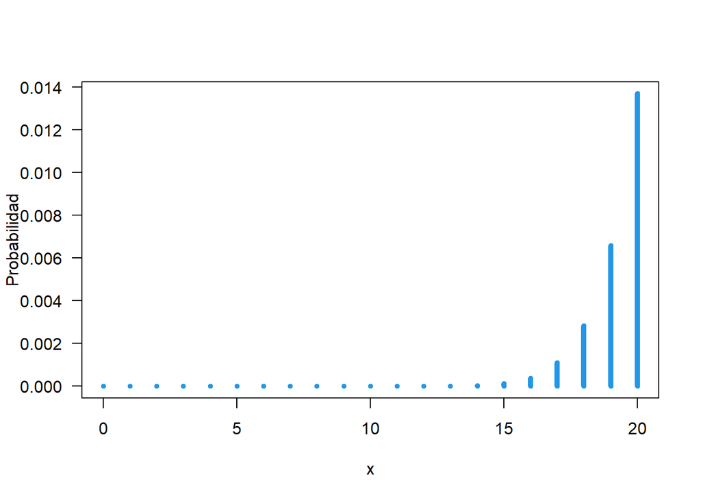

```r
x <- 0:20
Probabilidad <- dhyper(x=x, M,N-M,n)
plot(x=x, y=Probabilidad,
     type='h', las=1, lwd=5, col="68")
```

## **Fuentes bibliográficas**

- Alferez Vicente, B., & Calcina Huerta, A. M. (2020). Preferencia de los estudiantes de la universidad San Ignacio de Loyola hacia las marcas de celulares en el año 2019.
- URL: https://repositorio.usil.edu.pe/bitstreams/7b9f7ad9-385f-4202-9762-e1354e7002e8/download
- Ruiz Conejo Castillo, M., & Villavicencio Paz, A. (2015). Uso de dispositivos móviles para la práctica clínica en internos de medicina y médicos recién egresados de una universidad privada de Perú.
- URL: https://repositorio.upch.edu.pe/handle/20.500.12866/514?show=full